# Homework #5

Denitsa Vasileva

2019-10-17

# Setting up the Environment

```r
library(gapminder)
library(tidyverse)
library(here)
library(forcats)
library(ggplot2)
```

# Task #1

## The Value of the here Package

Frequently, the function setwd() is used in R scripts to set the script’s working directory while rm(list=ls()) is used to remove any variables from the environment. However, the here package provides a more convenient and reliable way to specify directories. First, using here allows for greater reproducibility of analysis. When using setwd() in your scripts, another user would have to reproduce the exact sub-directory structure of your files in order to be able to run your script. However, using the here package eliminates the need for this. Instead, the here package sets the root directory for your project and manipulates the paths within it. It is important to note here that the here package creates paths in a way that is not dependent on your machine’s operating system (e.g. macOS vs Windows). In addition, the here package allows for easier management of subdirectories. For example, it allows us to save the output of a script in a sub-directory different from the script’s own directory. Moreover, even if you have stored your scripts in an Rproject the here package allows them to run outside of their R project. Finally, the here package contains other useful functionalities such as set_here() which tags a directory as the root and dir_here() which explain why the function picked that particular directory as the working directory.

# Task #2

Dataset of choice- gapminder Variable of choice- Life Expectancy

## Dropping Oceania and Unused Factor Levels

```r
# Filtering out records with continent Oceania
gapminderDroppedLevels<-gapminder %>%
  filter(continent != "Oceania") %>%
  #Dropping unused levels
  droplevels()
```

## Number of Rows before Dropping Oceania and Unused Factor Levels

```r
gapminder %>%
  # number of rows in the gapminder dataset
  count()
```

```
## # A tibble: 1 x 1
##       n
##   <int>
## 1  1704
```

## Number of Rows after Dropping Oceania and Unused Factor Levels

```r
gapminderDroppedLevels %>%
  # number of rows after the dropping of the Oceania level
  count()
```

```
## # A tibble: 1 x 1
##       n
##   <int>
## 1  1680
```

## Number of factor levels before Dropping Oceania and Unused Factor Levels

```r
gapminder$continent %>%
  nlevels()
```

```
## [1] 5
```

```r
gapminder$country %>%
  nlevels()
```

```
## [1] 142
```

## Number of factor levels after Dropping Oceania and Unused Factor Levels

```r
# Country and continent are the factors in the dataset hence they are affected
# by dropping Oceania
gapminderDroppedLevels$continent %>%
  nlevels()
```

```
## [1] 4
```

```r
gapminderDroppedLevels$country %>%
  nlevels()
```

```
## [1] 140
```

## Reordering the levels of factor continent

### Levels of Factor continent Not Reordered

```r
gapminderDroppedLevels %>%
  arrange(continent) %>%
  DT::datatable()
```

|  | country | continent | year | lifeExp | pop | gdpPercap |
| --- | --- | --- | --- | --- | --- | --- |
| 1 | Algeria | Africa | 1952 | 43.077 | 9279525 | 2449.008185 |
| 2 | Algeria | Africa | 1957 | 45.685 | 10270856 | 3013.976023 |
| 3 | Algeria | Africa | 1962 | 48.303 | 11000948 | 2550.81688 |
| 4 | Algeria | Africa | 1967 | 51.407 | 12760499 | 3246.991771 |
| 5 | Algeria | Africa | 1972 | 54.518 | 14760787 | 4182.663766 |
| 6 | Algeria | Africa | 1977 | 58.014 | 17152804 | 4910.416756 |
| 7 | Algeria | Africa | 1982 | 61.368 | 20033753 | 5745.160213 |
| 8 | Algeria | Africa | 1987 | 65.799 | 23254956 | 5681.358539 |
| 9 | Algeria | Africa | 1992 | 67.744 | 26298373 | 5023.216647 |
| 10 | Algeria | Africa | 1997 | 69.152 | 29072015 | 4797.295051 |

[output cut: 1670 more lines]

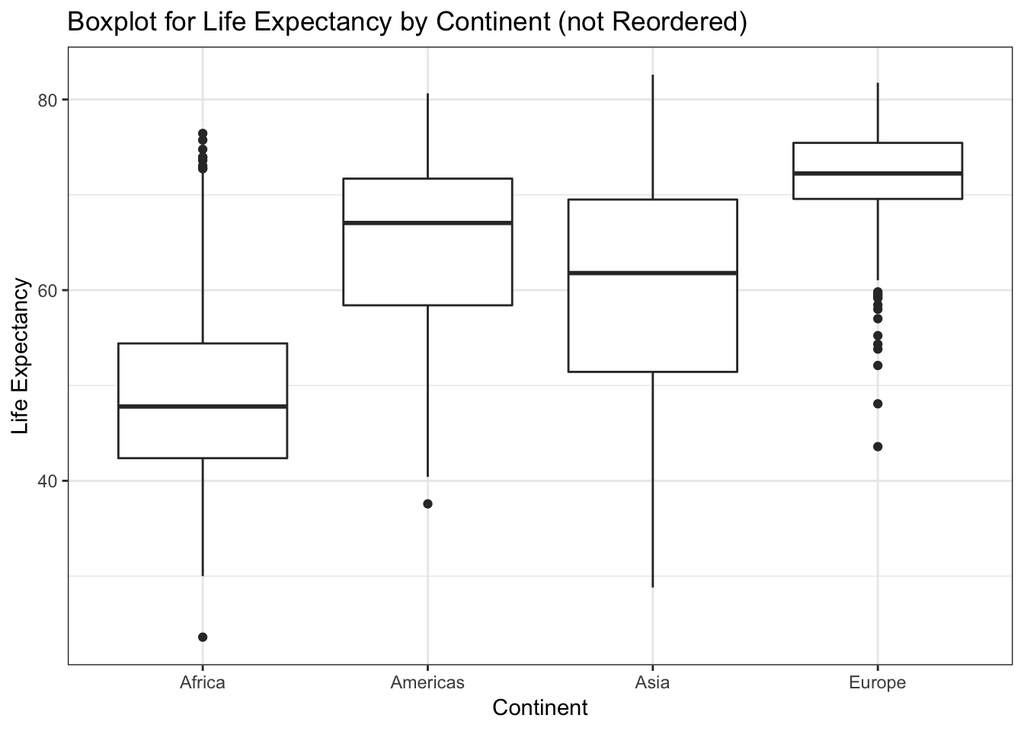

```r
gapminderDroppedLevels %>%
  # plotting life expectancy summary data for each continent after dropping
  # unused factor levels but before releveling the continent factor
  ggplot() +
  geom_boxplot(aes(y=lifeExp,x=continent)) +
  theme_bw()+xlab("Continents") + ggtitle("Boxplot for Life Expectancy by Continent (not Reordered)")+ xlab("Continent")+ylab("Life Expectancy")
```

### Levels of Factor Continent Reordered by Minimum GDP Per Capita

```r
gapminderDroppedLevels %>%
  arrange(fct_reorder(continent,gdpPercap,min)) %>%
  DT::datatable()
```

|  | country | continent | year | lifeExp | pop | gdpPercap |
| --- | --- | --- | --- | --- | --- | --- |
| 1 | Algeria | Africa | 1952 | 43.077 | 9279525 | 2449.008185 |
| 2 | Algeria | Africa | 1957 | 45.685 | 10270856 | 3013.976023 |
| 3 | Algeria | Africa | 1962 | 48.303 | 11000948 | 2550.81688 |
| 4 | Algeria | Africa | 1967 | 51.407 | 12760499 | 3246.991771 |
| 5 | Algeria | Africa | 1972 | 54.518 | 14760787 | 4182.663766 |
| 6 | Algeria | Africa | 1977 | 58.014 | 17152804 | 4910.416756 |
| 7 | Algeria | Africa | 1982 | 61.368 | 20033753 | 5745.160213 |
| 8 | Algeria | Africa | 1987 | 65.799 | 23254956 | 5681.358539 |
| 9 | Algeria | Africa | 1992 | 67.744 | 26298373 | 5023.216647 |
| 10 | Algeria | Africa | 1997 | 69.152 | 29072015 | 4797.295051 |

[output cut: 1670 more lines]

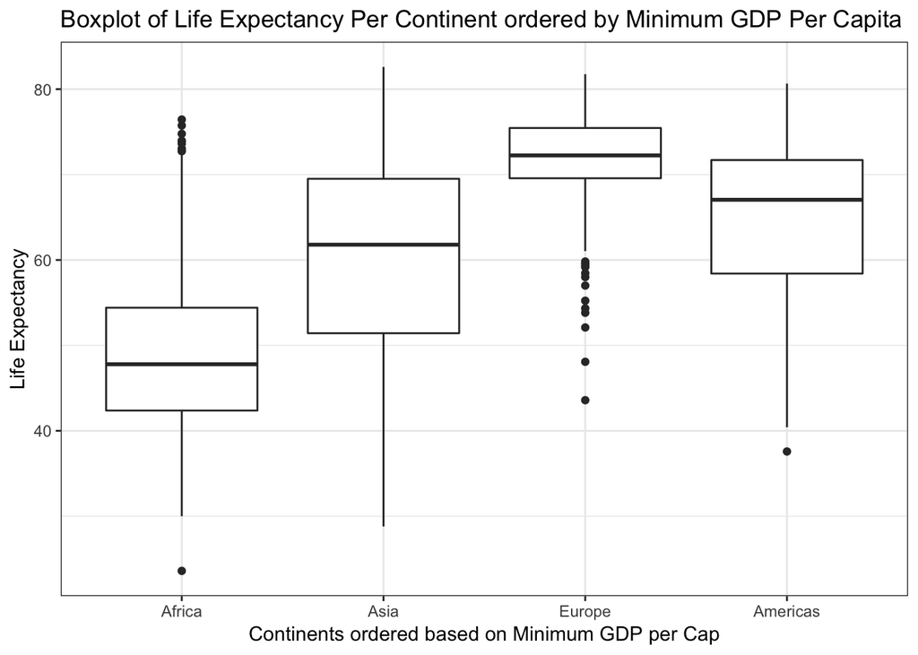

```r
gapminderDroppedLevels %>%
  # plotting life expectancy summary data for each continent after dropping
  # unused factor levels and after releveling the continent factor based on
  # minimum gdpPer cap
  ggplot() +
  geom_boxplot(aes(y=lifeExp,x=fct_reorder(continent,gdpPercap,min))) +
  theme_bw()+xlab("Continents ordered based on Minimum GDP per Cap")+ggtitle("Boxplot of Life Expectancy Per Continent ordered by Minimum GDP Per Capita") +ylab("Life Expectancy")
```

# Task 3

## Reading/Writing Data to Disk

```r
gapminder %>%
  select(continent,country,gdpPercap,year) %>%
  filter(year==2007) %>%
  group_by(continent) %>%
  # writing the filtered tibble to .csv file
  write_csv(here("hw_05","csv_continent_2007.csv"))
class(gapminder$continent)
```

```
## [1] "factor"
```

```r
class(gapminder$country)
```

```
## [1] "factor"
```

```r
# reading the .csv file in
gapminderGrouped<-read_csv(here("hw_05","csv_continent_2007.csv"))
class(gapminderGrouped$continent)
```

```
## [1] "character"
```

```r
class(gapminderGrouped$country)
```

```
## [1] "character"
```

The data written into file by write_csv() had been converted from factor to character upon parsing. The function as_factor() was used to convert it back to factor.

## Using Factors to Order Imported Data by Lowest to Highest Level Frequency

```r
gapminderGrouped$continent %>%
  # converting the continent variable into a factor
  as_factor() %>%
  # ordering levels based on fre2uency
  fct_infreq() %>%
  # Reverses order of frequency
  fct_rev() %>%
  levels()
```

```
## [1] "Oceania"  "Americas" "Europe"   "Asia"     "Africa"
```

However, this only reorders the factor continent and not the whole imported data.

In order to order all of the data (not just the continent factor as abive) we have to use arrange()

```r
gapminderGrouped %>%
  # arranges imported data by reverse (i.e.from lowest to highest ) frequency of continent
  arrange(fct_rev(fct_infreq(continent))) %>%
  DT::datatable()
```

|  | continent | country | gdpPercap | year |
| --- | --- | --- | --- | --- |
| 1 | Oceania | Australia | 34435.36744 | 2007 |
| 2 | Oceania | New Zealand | 25185.00911 | 2007 |
| 3 | Americas | Argentina | 12779.37964 | 2007 |
| 4 | Americas | Bolivia | 3822.137084 | 2007 |
| 5 | Americas | Brazil | 9065.800825 | 2007 |
| 6 | Americas | Canada | 36319.23501 | 2007 |
| 7 | Americas | Chile | 13171.63885 | 2007 |
| 8 | Americas | Colombia | 7006.580419 | 2007 |
| 9 | Americas | Costa Rica | 9645.06142 | 2007 |
| 10 | Americas | Cuba | 8948.102923 | 2007 |

[output cut: 132 more lines]

# Task 4

## Previous Graph vs New Graph

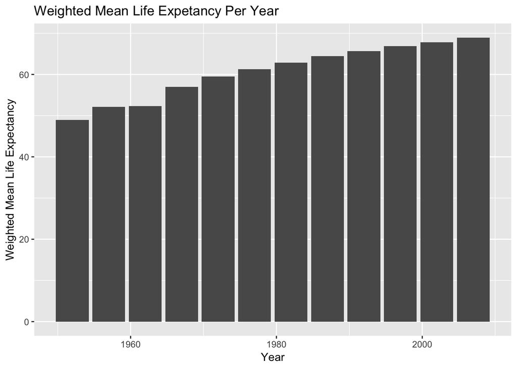

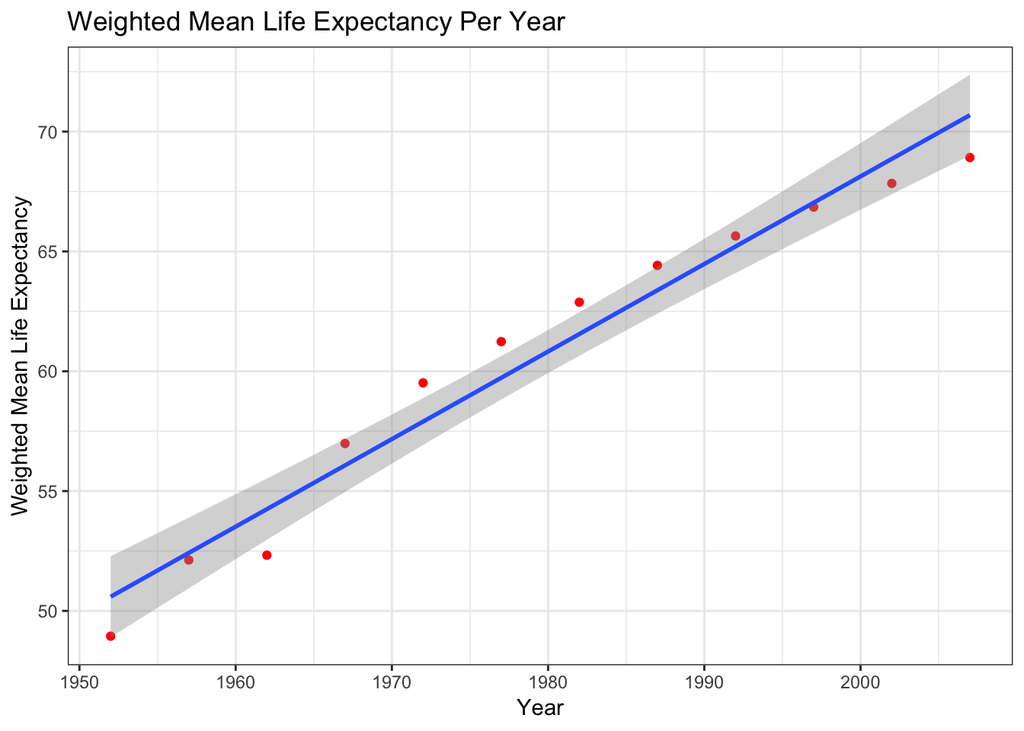

In the previous graph (on the left) the following principles of effective visualization had been broken:

- Choose your scale carefully- due to the graph being a bar plot, the x axis did not clearly show the exact year for each life Expectancy data point.
- Maintaining high data-to-ink ratio- the background was unnecessary and distracting.
- Choose type of graph wisely- bar plot was not as suited for graphically representing this relationship as a scatter plot does.
- Choose colours wisely- the grey colour scheme colours on the previous graph was not visually appealing. It did not grab attention or emphasize a trend in the data.

# Task 5

## Saving an image

```r
ggsave(here::here("hw_05","new_plot_1.png"), width=2,height=2,scale=2)
```

## Embedding an image

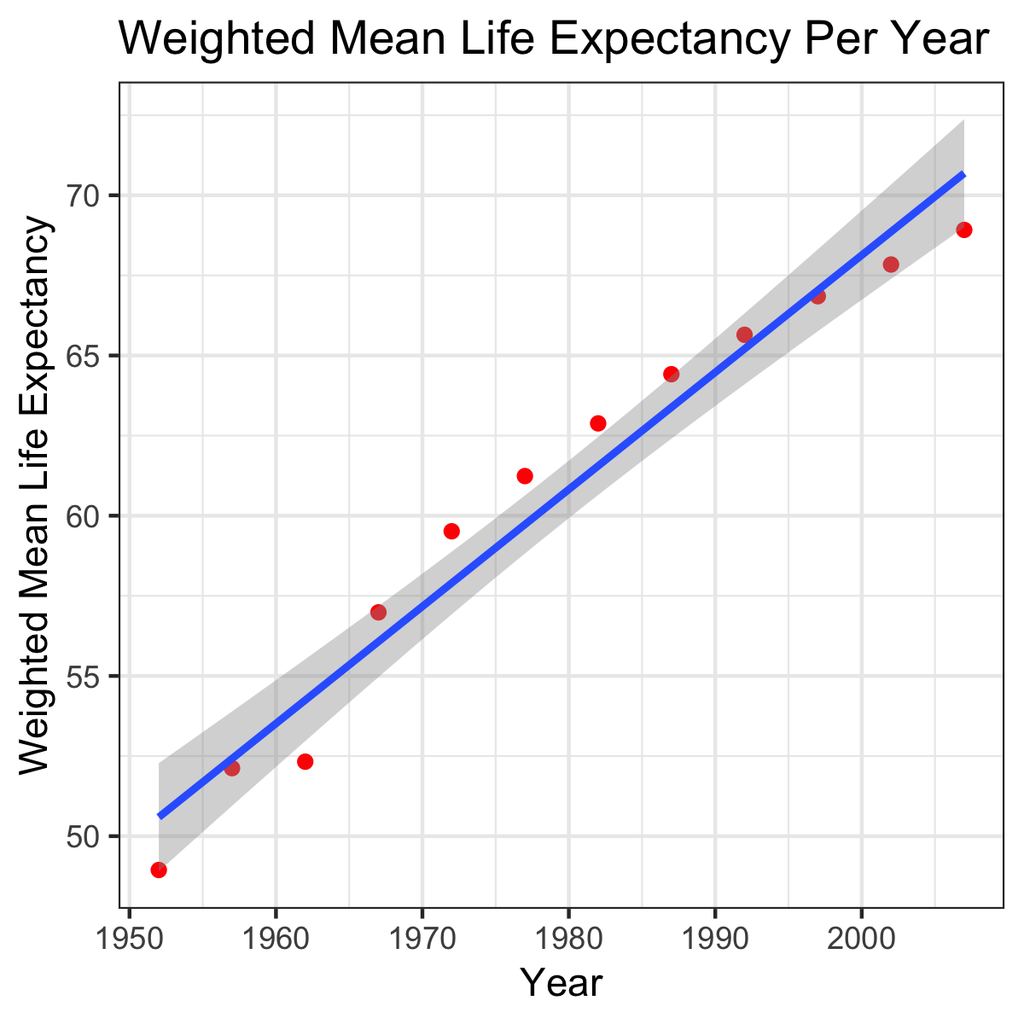

**Figure 1. New Graph of Weighted Mean Life Expectancy per Year**